# CS5701 — Week 2 Independent Lab

Tokoni Kunoun

2026-11-23

## Read in the auto-mpg.csv data set into your new R markdown file

I would use r to read the auto mpg file and assign it to a data frame called data

```r
  data <- read.csv("auto-mpg.csv")
```

## Explore the data (using summary statistics and plots) and check which columns from the continous variables look normally distributed.

```r
  str(data)
```

```
## 'data.frame':    398 obs. of  9 variables:
##  $ mpg         : num  18 15 18 16 17 15 14 14 14 15 ...
##  $ cylinders   : int  8 8 8 8 8 8 8 8 8 8 ...
##  $ displacement: num  307 350 318 304 302 429 454 440 455 390 ...
##  $ horsepower  : chr  "130" "165" "150" "150" ...
##  $ weight      : int  3504 3693 3436 3433 3449 4341 4354 4312 4425 3850 ...
##  $ acceleration: num  12 11.5 11 12 10.5 10 9 8.5 10 8.5 ...
##  $ model.year  : int  70 70 70 70 70 70 70 70 70 70 ...
##  $ origin      : int  1 1 1 1 1 1 1 1 1 1 ...
##  $ car.name    : chr  "chevrolet chevelle malibu" "buick skylark 320" "plymouth satellite" "amc rebel sst" ...
```

So from the output above, we can see that there are 398 observations of 9 variables. Out of the 9 variables, 7 are continous/numerical variables while two are categorical variables.

# I would now explore the continous/numerical variables to see which looks normally distributed.

# I would be examining the MPG variable for its distribution

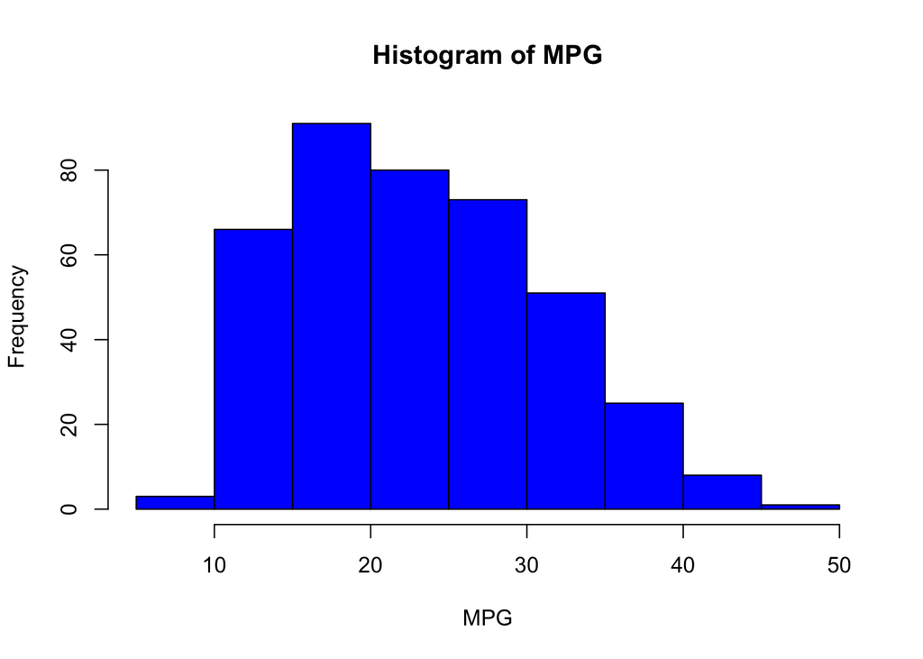

```r
  hist(data$mpg, main = "Histogram of MPG", xlab = "MPG", ylab = "Frequency", col = "blue")
```

This (MPG) leans towards right-skewed distribution.

# I would be examining the Cylinders variable for its distribution

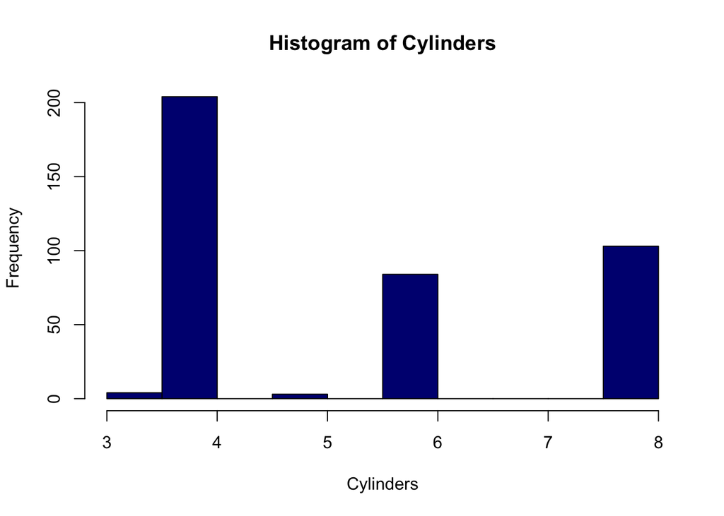

```r
  hist(data$cylinders, main = "Histogram of Cylinders", xlab = "Cylinders", ylab = "Frequency", col = "navy")
```

This (cylinders) is not a normally distributed histogram.

# I would be examining the Displacement variable for its distribution

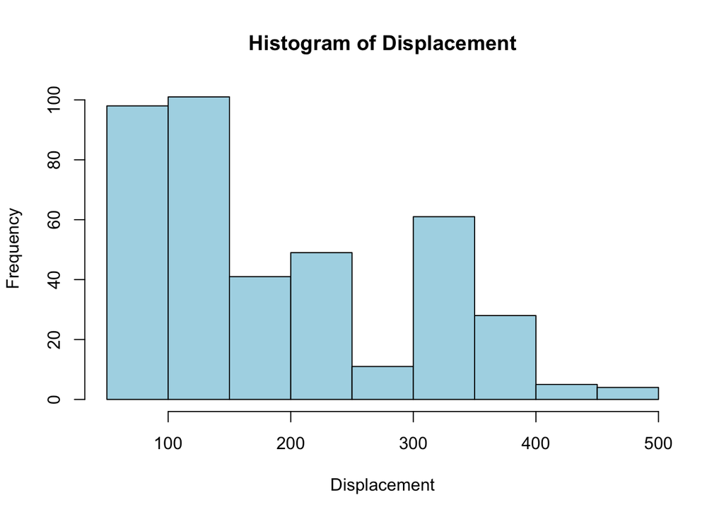

```r
  hist(data$displacement, main = "Histogram of Displacement", xlab = "Displacement", ylab = "Frequency", col = "lightblue")
```

This (Displacement) is not a normal distribution histogram.

# I would be examining the Weight variable for its distribution

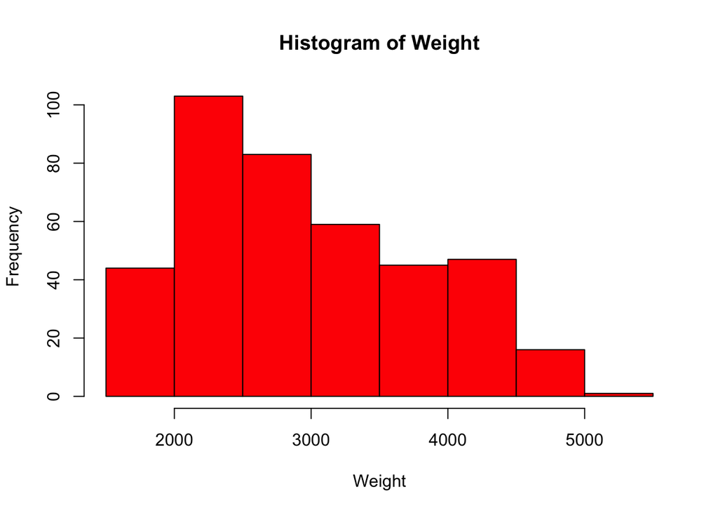

```r
  hist(data$weight, main = "Histogram of Weight", xlab = "Weight", ylab = "Frequency", col = "red")
```

This (Weight) is a right skewed distribution histogram.

# I would be examining the Acceleration variable for its distribution

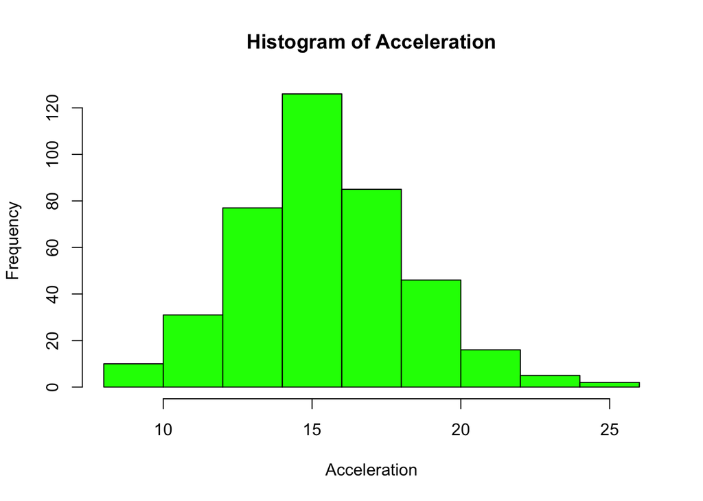

```r
  hist(data$acceleration, main = "Histogram of Acceleration", xlab = "Acceleration", ylab = "Frequency", col = "green")
```

The Acceleration histogram is a normal distribution histogram.

# I would be examining the Model.Year variable for its distribution

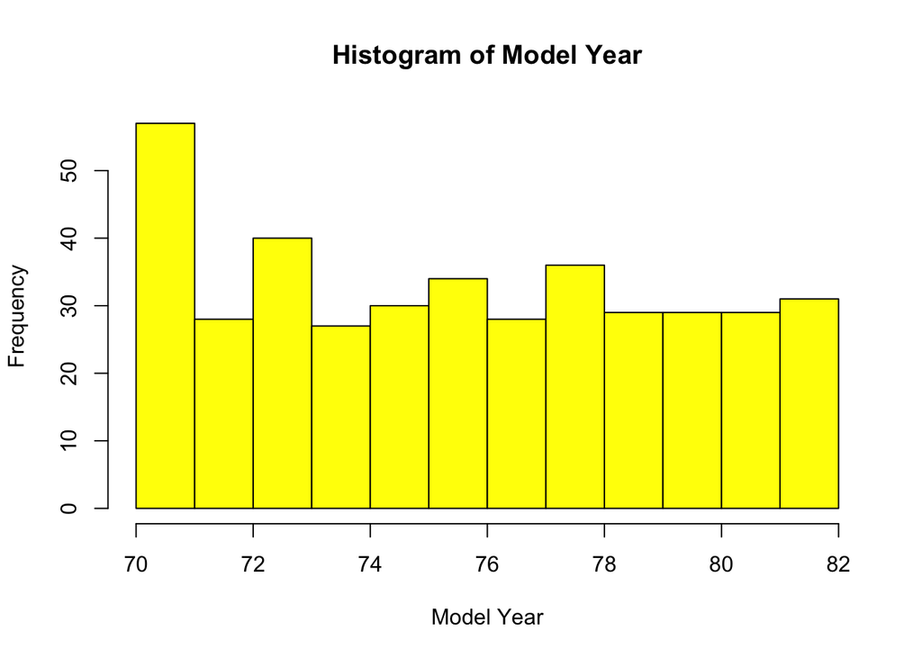

```r
  hist(data$model.year, main = "Histogram of Model Year", xlab = "Model Year", ylab = "Frequency", col = "yellow")
```

Model.year is not normally distributed.

# I would be examining the Origin variable for its distribution

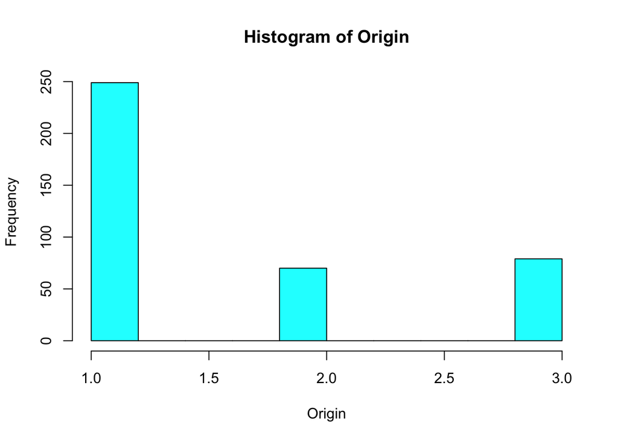

```r
  hist(data$origin, main = "Histogram of Origin", xlab = "Origin", ylab = "Frequency", col = "cyan")
```

The origin variable is not normally distributed.

# I would now explore the categorical variables using boxplot

# I would be examining the horsepower variable for its distribution

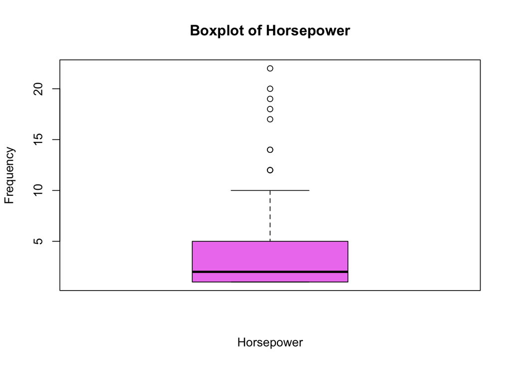

```r
  boxplot(table(data$horsepower), main = "Boxplot of Horsepower", xlab = "Horsepower", ylab = "Frequency", col = "violet")
```

I can’t comment on the distribution of this.

# I would be examining the Car name variable for its distribution

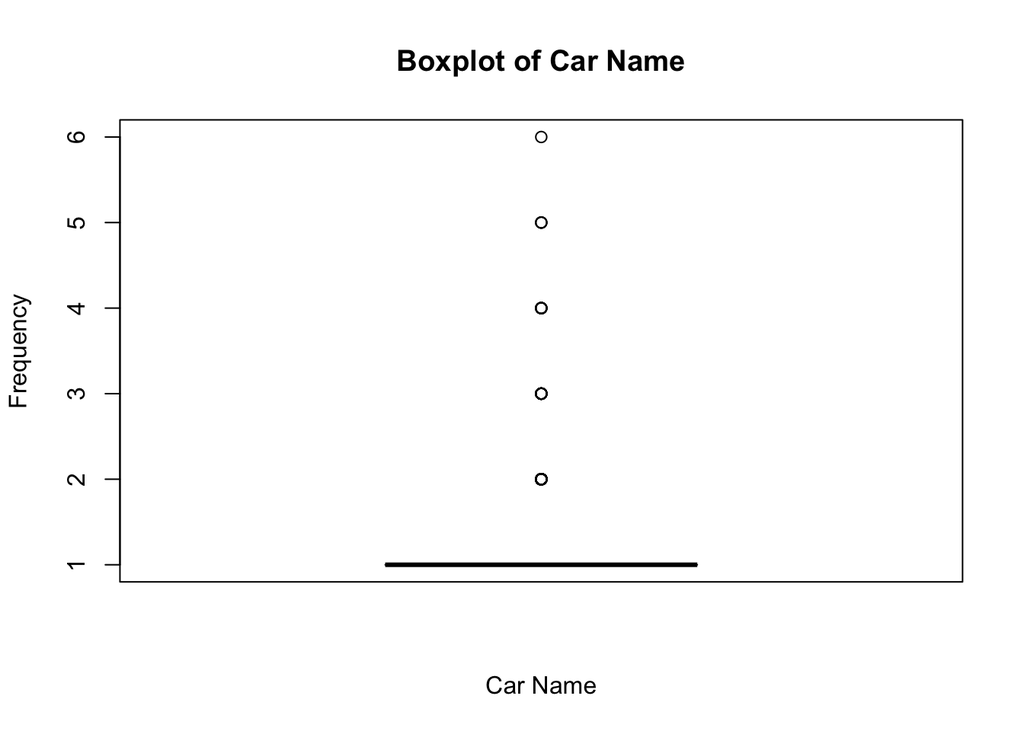

```r
  boxplot(table(data$car.name), main = "Boxplot of Car Name", xlab = "Car Name", ylab = "Frequency", col = "lightblue")
```

This is not normally distributed.

## Compute a 95% confidence interval for the mean for one of the variable that appears to be normally distributed.

```r
  t.test(data$acceleration, conf.level = 0.95)
```

```
##
##  One Sample t-test
##
## data:  data$acceleration
## t = 112.62, df = 397, p-value < 2.2e-16
## alternative hypothesis: true mean is not equal to 0
## 95 percent confidence interval:
##  15.29634 15.83985
## sample estimates:
## mean of x
##  15.56809
```

Acceleration appears to be normally distributed and I have computed the confidence interval for it. The 95% confidence interval for acceleration is 15.296 to 15.840, rounded to three decimal places.

## The model years range from the 70s and the 80s. What proportion of cars are from the 80s?

```r
   mean(data$model.year >= 80) * 100
```

```
## [1] 22.36181
```

Approximately 22.4% of cars are from the 80s

## Compute a 90% confidence interval for the proportion of cars from the 80s?

```r
  prop.test(sum(data$model.year >= 80), nrow(data), conf.level = 0.9)
```

```
##
##  1-sample proportions test with continuity correction
##
## data:  sum(data$model.year >= 80) out of nrow(data), null probability 0.5
## X-squared = 120.51, df = 1, p-value < 2.2e-16
## alternative hypothesis: true p is not equal to 0.5
## 90 percent confidence interval:
##  0.1900159 0.2610883
## sample estimates:
##         p
## 0.2236181
```

The 90% confidence interval for the proportion of cars from the 80s is between 0.19 and 0.26 rounded to two decimal place.

## Change the confidence level and track what happens to the width of the confidence interval for 6. and 8.

```r
  prop.test(sum(data$model.year >= 80), nrow(data), conf.level = 0.6)
```

```
##
##  1-sample proportions test with continuity correction
##
## data:  sum(data$model.year >= 80) out of nrow(data), null probability 0.5
## X-squared = 120.51, df = 1, p-value < 2.2e-16
## alternative hypothesis: true p is not equal to 0.5
## 60 percent confidence interval:
##  0.2053211 0.2429672
## sample estimates:
##         p
## 0.2236181
```

```r
  prop.test(sum(data$model.year >= 80), nrow(data), conf.level = 0.8)
```

```
##
##  1-sample proportions test with continuity correction
##
## data:  sum(data$model.year >= 80) out of nrow(data), null probability 0.5
## X-squared = 120.51, df = 1, p-value < 2.2e-16
## alternative hypothesis: true p is not equal to 0.5
## 80 percent confidence interval:
##  0.1968209 0.2527932
## sample estimates:
##         p
## 0.2236181
```

The width gets narrower as the confidence level reduces.